# Regressão Linear

## Introdução:

A regressão linear é uma técnica estatística usada para analisar e modelar relações lineares entre uma variável dependente e uma ou mais variáveis independentes. Se a relação entre as variáveis for linear, então uma linha reta pode ser ajusta aos dados para modelar a relação entre elas. A equação de regressão linear (ou a equação para uma linha reta) bivariada toma a seguinte forma:

$$Y = \beta_{0} + \beta_{1}X$$
Sendo $Y$ a *variável dependente ou resposta*, $\beta_{0}$ a intersecção com o eixo Y, $\beta_{1}$ o coeficiente angular da reta.

A análise de regressão é uma técnica que permite estimar o comportamento médio, de uma variável resposta em relação a uma ou mais variáveis explicativas.Por exemplo, estimar a altura média dos filhos a partir da altura de seus pais, estimar quanto um motor pode consumir de combustível, baseado na sua potência média, etc.

## Estudo de caso: A altura é hereditária ?

A teoria e desenvolvimento das técnicas necessárias para conduzir a regressão, surgiram com o matemático, estatístico e antropólogo Francis Galton. Galton coletou, e estudou dados de altura entre familiares, com o objetivo de tentar entender a hereditariedade. Enquanto fazia seus estudos, ele desenvolveu os conceitos de **correlação** e **regressão**, como também de pares de dados que seguem uma distribuição normal. Ao estudar as estaturas de pais e filhos, Galton observou que filhos de pais com altura baixa em relação à média tendem a ser mais altos que seus pais, e filhos de pais com estatura alta em relação à média tendem a ser mais baixos que seus pais, ou seja, as alturas dos seres humanos em geral tendem a **regredir** a média.

Vamos examinar o dataset e verificar a sua estrutura.

```r
str(GaltonFamilies)
```

```
'data.frame':   934 obs. of  8 variables:
 $ family         : Factor w/ 205 levels "001","002","003",..: 1 1 1 1 2 2 2 2 3 3 ...
 $ father         : num  78.5 78.5 78.5 78.5 75.5 75.5 75.5 75.5 75 75 ...
 $ mother         : num  67 67 67 67 66.5 66.5 66.5 66.5 64 64 ...
 $ midparentHeight: num  75.4 75.4 75.4 75.4 73.7 ...
 $ children       : int  4 4 4 4 4 4 4 4 2 2 ...
 $ childNum       : int  1 2 3 4 1 2 3 4 1 2 ...
 $ gender         : Factor w/ 2 levels "female","male": 2 1 1 1 2 2 1 1 2 1 ...
 $ childHeight    : num  73.2 69.2 69 69 73.5 72.5 65.5 65.5 71 68 ...
```

Neste dataset, temos 8 variáveis(as importantes para o nosso estudo são, pais, mães, filhos e filhas). Primeiro vamos criar 2 conjuntos de pares de dados, **pais - filhos (male)** e **mulheres - filhas (female)**

```r
set.seed(1983)
galton.heights_male <- GaltonFamilies %>%
      filter(gender == "male") %>%
      group_by(family) %>%
      sample_n(1) %>%
      ungroup() %>%
      select(father, childHeight) %>%
      rename(son = childHeight)

str(galton.heights_male)
```

```
Classes ‘tbl_df’, ‘tbl’ and 'data.frame':   179 obs. of  2 variables:
 $ father: num  78.5 75.5 75 75 75 74 74 73 73 73 ...
 $ son   : num  73.2 73.5 71 68.5 68 76.5 74 71 68 71 ...
```

```r
set.seed(1983)
galton.heights_female <- GaltonFamilies %>%
      filter(gender == "female") %>%
      group_by(family) %>%
      sample_n(1) %>%
      ungroup() %>%
      select(mother, childHeight) %>%
      rename(daughter = childHeight)

str(galton.heights_female)
```

```
Classes ‘tbl_df’, ‘tbl’ and 'data.frame':   176 obs. of  2 variables:
 $ mother  : num  67 66.5 64 64 58.5 68 68 66.5 66 65.5 ...
 $ daughter: num  69 65.5 68 63 62.5 69.5 70.5 70.5 66 65.5 ...
```

Vamos dar uma olhada nas distribuições para ver se tem distribuições normais.

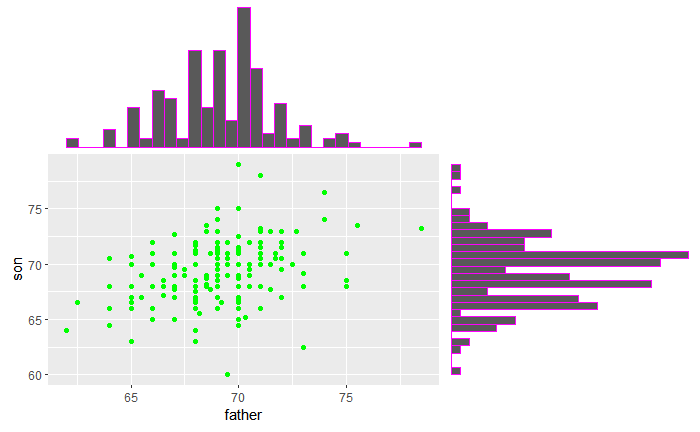

```r
p <- galton.heights_male %>%
     ggplot(aes(x = father, y = son)) +
     geom_point(color = 'green') +
     theme(legend.position = 'none')

p1 <- ggMarginal(p, type = 'hist', color = 'magenta', size = 1.5)
p1
```

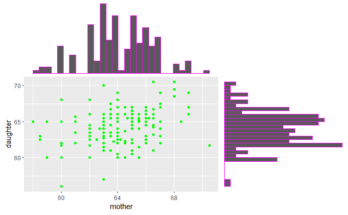

```r
p <- galton.heights_female %>%
     ggplot(aes(x = mother, y = daughter)) +
     geom_point(color = 'green') +
     theme(legend.position = 'none')

p1 <- ggMarginal(p, type = 'hist', color = 'magenta', size = 1.5)
p1
```

Agora que olhamos as distribuições dos pares (pais/filhos e mães/filhas), vamos prosseguir fazendo um resumo estatístico destes pares.

```r
galton.heights_male %>%
    summarize(mean(father), sd(father), mean(son), sd(son))
```

| mean(father) | sd(father) | mean(son) | sd(son) |
| --- | --- | --- | --- |
| 69.099 | 2.5466 | 69.246 | 2.8794 |

Podemos observar nesse gráfico, que a medida que altura do pai cresce a altura do respectivo filho também. Vamos o resumo para os dados das mães/filhas.

```r
galton.heights_female %>%
    summarize(mean(mother), sd(mother), mean(daughter), sd(daughter))
```

| mean(mother) | sd(mother) | mean(daughter) | sd(daughter) |
| --- | --- | --- | --- |
| 64.125 | 2.2893 | 64.2 | 2.4432 |

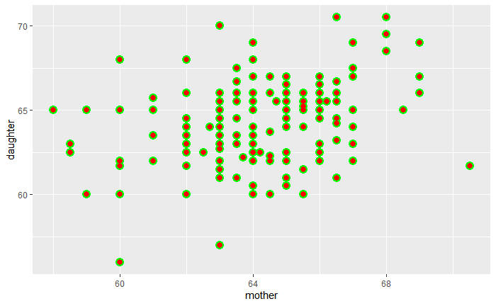

```r
galton.heights_female %>%
  ggplot(aes(mother, daughter)) +
  geom_point(color = 'green', size = 4, alpha = 1) +
  geom_point(color = 'red', size = 2.5, alpha = 1)
```